# Earth_Mars_SEP_Pyoptgra

## Trajectory optimisation example

This example shows how to use pyoptgra to optimise a trajectory using the GODOT cosmos module.

It was created by Gabor Varga as part of the Godot tutorials, he generously gave permission to reproduce it here.

First we load some python packages for plotting and linear algebra.

```python
%matplotlib inline
import numpy as np
import matplotlib.pyplot as plt
```

Then we load godot specific libraries and the pygmo optimisation package

```python
from godot.core import tempo, util, constants
from godot.core import autodif as ad
from godot.core.autodif import bridge as br
from godot.model import interface
from godot import cosmos
import pygmo
import pygmo_plugins_nonfree
```

```python
import pyoptgra
```

Load the [universe configuration](https://orbit_software.io.esa.int/godot-tutorials/T10_OptimiseTrajectory/universe.yml) and create the universe object

```python
util.suppressLogger()
uni_config = cosmos.util.load_yaml('universe.yml')
uni = cosmos.Universe(uni_config)
```

Load the [trajectory configuration](https://orbit_software.io.esa.int/godot-tutorials/T10_OptimiseTrajectory/trajectory.yml) and create the trajectory object using the universe object

```python
tra_config = cosmos.util.load_yaml('trajectory.yml')
tra = cosmos.Trajectory(uni, tra_config)
```

We generate a plotting function to create visualization for our trajectory in the solar system.

```python
def man_data(name):
    start = tra.point(f"{name}_start")
    end = tra.point(f"{name}_end")
    ran = tempo.EpochRange(start, end)
    grid = ran.createGrid(1.0 * tempo.SecondsInDay)
    t = [e.mjd() for e in grid]
    r = np.asarray([uni.frames.vector3('Sun', 'SC_center', 'EMC', e) / constants.AU for e in grid])
    thr = np.asarray([uni.evaluables["SC_sep_thrust"].eval(e) for e in grid])
    return t, r, thr

def plot():
    ran = tempo.EpochRange(tempo.Epoch("2020-01-01 TDB"), tempo.Epoch("2022-01-01 TDB"))
    earth = np.asarray([uni.frames.vector3('Sun', 'Earth', 'EMC', e) / constants.AU for e in ran.createGrid(1.0 * tempo.SecondsInDay)])
    mars = np.asarray([uni.frames.vector3('Sun', 'Mars', 'EMC', e) / constants.AU for e in ran.createGrid(1.0 * tempo.SecondsInDay)])

    def pos(e):
        try:
            return uni.frames.vector3('Sun', 'SC_center', 'EMC', e) / constants.AU
        except:
            return [np.nan] * 3

    grid = tra.range().createGrid(1.0 * tempo.SecondsInDay)
    t = [e.mjd() for e in grid]
    x = np.asarray([pos(e) for e in grid])

    man1_t, man1_r, man1_thr = man_data("man1")
    man2_t, man2_r, man2_thr = man_data("man2")

    plt.figure(figsize=(8, 8))

    plt.xlabel('EMC X (AU)')
    plt.ylabel('EMC Y (AU)')
    plt.plot(earth[:, 0], earth[:, 1], '--', label="Earth")
    plt.plot(mars[:, 0], mars[:, 1], '--', label="Mars")
    plt.plot(x[:, 0], x[:, 1], '-k', linewidth=2, label="Transfer")
    plt.plot(man1_r[:, 0], man1_r[:, 1], '-r', linewidth=4, label="SEP 1")
    plt.plot(man2_r[:, 0], man2_r[:, 1], '-g', linewidth=4, label="SEP 2")
    plt.plot(x[0, 0], x[0, 1], 'ok')
    plt.plot(x[-1, 0], x[-1, 1], 'ok')
    plt.xlim([-2, 2])
    plt.ylim([-2, 2])
    plt.legend()
    plt.grid()

    plt.figure(figsize=(8, 4))
    plt.xlabel('Time (MJD)')
    plt.ylabel('SEP thrust (mN)')
    plt.plot(man1_t, 1e6 * man1_thr, '-r', linewidth=3, label="SEP 1")
    plt.plot(man2_t, 1e6 * man2_thr, '-g', linewidth=3, label="SEP 2")
    plt.xlim([9750, 10150])
    plt.ylim([0, 1000])
    plt.legend()
    plt.grid()
```

We compute the initial guess of the transfer trajectory and visualize it.

Immediately we can see that there is a large discontinuity at the matching point and this optimisation problem needs to be solved.

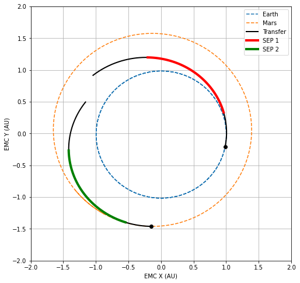

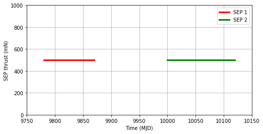

```python
tra.compute(False)
plot()
```

Load the [problem configuration](https://orbit_software.io.esa.int/godot-tutorials/T10_OptimiseTrajectory/problem.yml) and create the problem object using the universe, a list of considered trajectories

```python
pro_config = cosmos.util.load_yaml('problem.yml')
pro = cosmos.Problem(uni, [tra], pro_config)
```

Now it is time to create the pygmo problem class that simply takes ours, and define some constraint tolerances

```python
problem = pygmo.problem(pro)
conTol = 1e-6
problem.c_tol = [conTol] * problem.get_nc()
```

We create the pygmo population to be optimised by grabbing the initial value of the free parameters

```python
x0 = pro.get_x()
pop = pygmo.population(problem, 0)
pop.push_back(x0)
```

Finally we use pyoptgra to optimise the problem

```python
algo = pygmo.algorithm(pyoptgra.optgra())
algo.set_verbosity(1)
pop = algo.evolve(pop)
```

We can visualize the final converged trajectory.

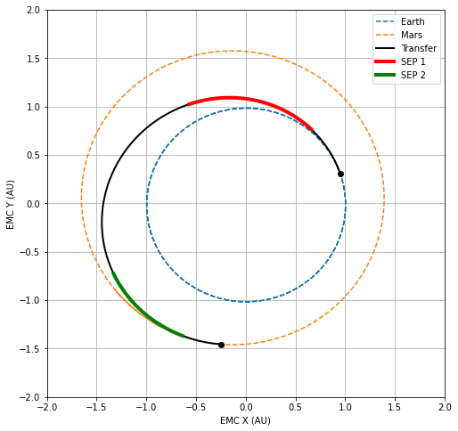

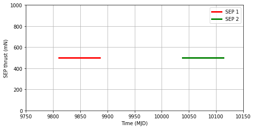

```python
plot()
```

Finally, we can save the optimised and updated trajectory configuration

```python
up = tra.applyParameterChanges()
tra_config = cosmos.util.deep_update(tra_config, up)
cosmos.util.save_yaml(tra_config, 'trajectory_out.yml')
```